# Practice Machine Learning- Coursera

Stefano Arcuri

26 dicembre 2015

### Introduction

(this is from exercise specification)

Using devices such as *Jawbone Up, Nike FuelBand, and Fitbit* it is now possible to collect a large amount of data about personal activity relatively inexpensively. These type of devices are part of the quantified self movement – a group of enthusiasts who take measurements about themselves regularly to improve their health, to find patterns in their behavior, or because they are tech geeks. One thing that people regularly do is quantify how much of a particular activity they do, but they rarely quantify how well they do it. In this project, your goal will be to use data from accelerometers on the belt, forearm, arm, and dumbell of 6 participants. They were asked to perform barbell lifts correctly and incorrectly in 5 different ways. More information is available from the website here: http://groupware.les.inf.puc-rio.br/har (see the section on the Weight Lifting Exercise Dataset).

### Goal

In this project, we will use data from accelerometers on the belt, forearm, arm, and dumbell of 6 participants. They were asked to perform barbell lifts correctly and incorrectly in 5 different ways:

Class A: exactly according to the specification Class B: throwing the elbows to the front Class C: lifting the dumbbell only halfway Class D: lowering the dumbbell only halfway Class E: throwing the hips to the front

More information is available from the website here: http://groupware.les.inf.puc-rio.br/har (see the section on the Weight Lifting Exercise Dataset)

### My Considerations about criteria

I tried with frustration various techniques as bagging and random forest, but due to limitation of my machine (4gb RAM - not sure the reason is this) I had to choose for lightest criterias, so I applied the decision trees in two ways.

### Load libraries

```r
library (caret);library (kernlab)
```

### Load data

```r
trainUrl <- "http://d396qusza40orc.cloudfront.net/predmachlearn/pml-training.csv"
testUrl <- "http://d396qusza40orc.cloudfront.net/predmachlearn/pml-testing.csv"
training <- read.csv(url(trainUrl), header=TRUE, sep=",", na.strings=c("NA","#DIV/0!",""))
test <- read.csv(url(testUrl), header=TRUE, sep=",", na.strings=c("NA","#DIV/0!",""))
```

### Analyze data

```r
str(training[, ])
```

```
## 'data.frame':    19622 obs. of  160 variables:
##  $ X                       : int  1 2 3 4 5 6 7 8 9 10 ...
##  $ user_name               : Factor w/ 6 levels "adelmo","carlitos",..: 2 2 2 2 2 2 2 2 2 2 ...
##  $ raw_timestamp_part_1    : int  1323084231 1323084231 1323084231 1323084232 1323084232 1323084232 1323084232 1323084232 1323084232 1323084232 ...
##  $ raw_timestamp_part_2    : int  788290 808298 820366 120339 196328 304277 368296 440390 484323 484434 ...
##  $ cvtd_timestamp          : Factor w/ 20 levels "02/12/2011 13:32",..: 9 9 9 9 9 9 9 9 9 9 ...
##  $ new_window              : Factor w/ 2 levels "no","yes": 1 1 1 1 1 1 1 1 1 1 ...
##  $ num_window              : int  11 11 11 12 12 12 12 12 12 12 ...
##  $ roll_belt               : num  1.41 1.41 1.42 1.48 1.48 1.45 1.42 1.42 1.43 1.45 ...
##  $ pitch_belt              : num  8.07 8.07 8.07 8.05 8.07 8.06 8.09 8.13 8.16 8.17 ...
##  $ yaw_belt                : num  -94.4 -94.4 -94.4 -94.4 -94.4 -94.4 -94.4 -94.4 -94.4 -94.4 ...
##  $ total_accel_belt        : int  3 3 3 3 3 3 3 3 3 3 ...
##  $ kurtosis_roll_belt      : num  NA NA NA NA NA NA NA NA NA NA ...
##  $ kurtosis_picth_belt     : num  NA NA NA NA NA NA NA NA NA NA ...
##  $ kurtosis_yaw_belt       : logi  NA NA NA NA NA NA ...
```

[output cut: 86 more lines]

```r
summary(training)
```

[output not shown]

[output cut: 313 more lines]

```
##  Min.   :-446.00   Min.   :-1280.0   Min.   :-896.0   Min.   :-973.0
##  1st Qu.:-182.00   1st Qu.: -616.0   1st Qu.:   2.0   1st Qu.: 191.0
##  Median : -39.00   Median : -378.0   Median : 591.0   Median : 511.0
##  Mean   : -55.29   Mean   : -312.6   Mean   : 380.1   Mean   : 393.6
##  3rd Qu.:  26.00   3rd Qu.:  -73.0   3rd Qu.: 737.0   3rd Qu.: 653.0
##  Max.   : 291.00   Max.   :  672.0   Max.   :1480.0   Max.   :1090.0
##
##  classe
##  A:5580
##  B:3797
##  C:3422
##  D:3216
##  E:3607
##
##
```

```r
summary(test)
```

[output not shown]

[output cut: 289 more lines]

```
##  Min.   :-1.2600   Min.   :-212.0   Min.   :-331.0   Min.   :-282.0
##  1st Qu.:-0.0975   1st Qu.:-114.8   1st Qu.:   8.5   1st Qu.:-199.0
##  Median : 0.2300   Median :  86.0   Median : 138.0   Median :-148.5
##  Mean   : 0.2610   Mean   :  38.8   Mean   : 125.3   Mean   : -93.7
##  3rd Qu.: 0.7625   3rd Qu.: 166.2   3rd Qu.: 268.0   3rd Qu.: -31.0
##  Max.   : 1.8000   Max.   : 232.0   Max.   : 406.0   Max.   : 179.0
##
##  magnet_forearm_x magnet_forearm_y magnet_forearm_z   problem_id
##  Min.   :-714.0   Min.   :-787.0   Min.   :-32.0    Min.   : 1.00
##  1st Qu.:-427.2   1st Qu.:-328.8   1st Qu.:275.2    1st Qu.: 5.75
##  Median :-189.5   Median : 487.0   Median :491.5    Median :10.50
##  Mean   :-159.2   Mean   : 191.8   Mean   :460.2    Mean   :10.50
##  3rd Qu.:  41.5   3rd Qu.: 720.8   3rd Qu.:661.5    3rd Qu.:15.25
##  Max.   : 532.0   Max.   : 800.0   Max.   :884.0    Max.   :20.00
##
```

### REmove columns NA

removing columns with NA

```r
indexNA <- as.vector(sapply(training[,1:152],function(x) {length(which(is.na(x)))!=0}))
training <- training [,!indexNA]
test <- test[,!indexNA]
```

### HCV

removing high correlated variables. I noticed that raising the cutoff the accuracy increases.

[figure not shown]

### Preprocessing

```r
preProcValues <- preProcess(training, method = c("center", "scale"))
trainTransformed <- predict(preProcValues, training)
testTransformed <- predict(preProcValues, test)
```

### Near Zero Variance

```r
nzv <- nearZeroVar(trainTransformed,saveMetrics=TRUE)
as.data.frame(nzv)
```

```
##                      freqRatio percentUnique zeroVar   nzv
## pitch_belt            1.036082     9.3772296   FALSE FALSE
## yaw_belt              1.058480     9.9734991   FALSE FALSE
## total_accel_belt      1.063160     0.1477933   FALSE FALSE
## gyros_belt_x          1.058651     0.7134849   FALSE FALSE
## gyros_belt_y          1.144000     0.3516461   FALSE FALSE
## gyros_belt_z          1.066214     0.8612782   FALSE FALSE
## accel_belt_x          1.055412     0.8357966   FALSE FALSE
## accel_belt_y          1.113725     0.7287738   FALSE FALSE
## magnet_belt_x         1.090141     1.6664968   FALSE FALSE
## magnet_belt_y         1.099688     1.5187035   FALSE FALSE
## magnet_belt_z         1.006369     2.3290184   FALSE FALSE
## roll_arm             52.338462    13.5256345   FALSE FALSE
## pitch_arm            87.256410    15.7323412   FALSE FALSE
## yaw_arm              33.029126    14.6570176   FALSE FALSE
## total_accel_arm       1.024526     0.3363572   FALSE FALSE
## gyros_arm_x           1.015504     3.2769341   FALSE FALSE
## gyros_arm_y           1.454369     1.9162165   FALSE FALSE
## gyros_arm_z           1.110687     1.2638875   FALSE FALSE
## accel_arm_x           1.017341     3.9598410   FALSE FALSE
## accel_arm_y           1.140187     2.7367241   FALSE FALSE
## accel_arm_z           1.128000     4.0362858   FALSE FALSE
## magnet_arm_x          1.000000     6.8239731   FALSE FALSE
## magnet_arm_y          1.056818     4.4439914   FALSE FALSE
## magnet_arm_z          1.036364     6.4468454   FALSE FALSE
## roll_dumbbell         1.022388    84.2065029   FALSE FALSE
## pitch_dumbbell        2.277372    81.6685353   FALSE FALSE
## yaw_dumbbell          1.132231    83.4828254   FALSE FALSE
## total_accel_dumbbell  1.072634     0.2191418   FALSE FALSE
## gyros_dumbbell_x      1.003268     1.2282132   FALSE FALSE
## gyros_dumbbell_y      1.264957     1.4167771   FALSE FALSE
## accel_dumbbell_x      1.018018     2.1659362   FALSE FALSE
## accel_dumbbell_y      1.053061     2.3748853   FALSE FALSE
## accel_dumbbell_z      1.133333     2.0894914   FALSE FALSE
## magnet_dumbbell_x     1.098266     5.7486495   FALSE FALSE
## magnet_dumbbell_y     1.197740     4.3012945   FALSE FALSE
## magnet_dumbbell_z     1.020833     3.4451126   FALSE FALSE
## roll_forearm         11.589286    11.0895933   FALSE FALSE
## pitch_forearm        65.983051    14.8557741   FALSE FALSE
## yaw_forearm          15.322835    10.1467740   FALSE FALSE
## total_accel_forearm   1.128928     0.3567424   FALSE FALSE
## gyros_forearm_x       1.059273     1.5187035   FALSE FALSE
## gyros_forearm_y       1.036554     3.7763735   FALSE FALSE
## gyros_forearm_z       1.122917     1.5645704   FALSE FALSE
## accel_forearm_x       1.126437     4.0464784   FALSE FALSE
## accel_forearm_y       1.059406     5.1116094   FALSE FALSE
## accel_forearm_z       1.006250     2.9558659   FALSE FALSE
## magnet_forearm_x      1.012346     7.7667924   FALSE FALSE
## magnet_forearm_y      1.246914     9.5403119   FALSE FALSE
## magnet_forearm_z      1.000000     8.5771073   FALSE FALSE
## classe                1.469581     0.0254816   FALSE FALSE
```

```r
trainTransformed <- trainTransformed[,nzv$nzv==FALSE]
testTransformed <- testTransformed[,nzv$nzv==FALSE]
```

### load library rpart

```r
library(rpart)
library(rpart.plot)
library(rattle)
library(caret)
```

### Decision trees

[figure not shown]

```r
dectree <- rpart(classe ~ ., data=xtraining, method="class")
fancyRpartPlot(dectree)
```

### Decision trees2

```r
dectree2 <- train(classe ~ .,method="rpart",data=xtraining)
print (dectree2$finalModel)
```

```
## n= 16680
##
## node), split, n, loss, yval, (yprob)
##       * denotes terminal node
##
##  1) root 16680 11937 A (0.28 0.19 0.17 0.16 0.18)
##    2) pitch_forearm< -1.588387 1360     6 A (1 0.0044 0 0 0) *
##    3) pitch_forearm>=-1.588387 15320 11931 A (0.22 0.21 0.19 0.18 0.2)
##      6) magnet_belt_y>=-1.069957 14077 10691 A (0.24 0.23 0.21 0.18 0.15)
##       12) magnet_dumbbell_y< 0.6288045 11573  8288 A (0.28 0.18 0.24 0.17 0.12)
##         24) roll_forearm< 0.8207781 7234  4285 A (0.41 0.18 0.18 0.15 0.089) *
##         25) roll_forearm>=0.8207781 4339  2857 C (0.077 0.18 0.34 0.22 0.18)
##           50) accel_forearm_x>=-0.2483375 3068  1889 C (0.087 0.22 0.38 0.09 0.22) *
##           51) accel_forearm_x< -0.2483375 1271   601 D (0.055 0.087 0.24 0.53 0.092) *
##       13) magnet_dumbbell_y>=0.6288045 2504  1352 B (0.04 0.46 0.045 0.21 0.25) *
##      7) magnet_belt_y< -1.069957 1243   224 E (0.0024 0.0032 0.0008 0.17 0.82) *
```

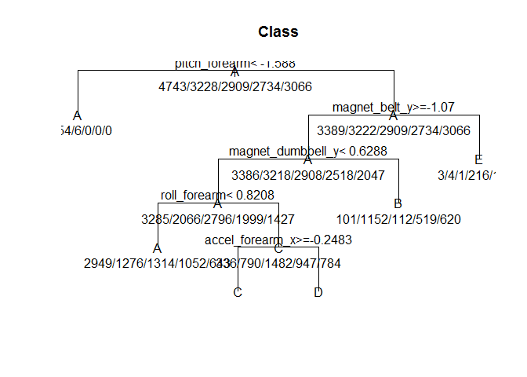

```r
plot (dectree2$finalModel,uniform = TRUE, main="Class")
text (dectree2$finalModel, use.n=TRUE, all=TRUE, cex=1.0)
```

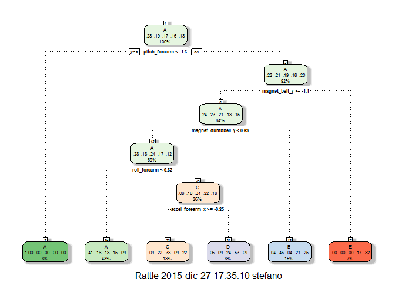

```r
fancyRpartPlot(dectree2$finalModel)
```

### Legend

Class A: exactly according to the specification Class B: throwing the elbows to the front Class C: lifting the dumbbell only halfway Class D: lowering the dumbbell only halfway Class E: throwing the hips to the front

### Cross Validation

```r
a<-predict (dectree2, newdata = xtesting)
confusionMatrix(a, xtesting$classe)
```

```
## Confusion Matrix and Statistics
##
##           Reference
## Prediction   A   B   C   D   E
##          A 751 237 252 179 116
##          B  22 196  17  97 114
##          C  51 114 194  44 120
##          D  13  22  49 112  20
##          E   0   0   1  50 171
##
## Overall Statistics
##
##                Accuracy : 0.484
##                  95% CI : (0.4658, 0.5023)
##     No Information Rate : 0.2845
##     P-Value [Acc > NIR] : < 2.2e-16
##
##                   Kappa : 0.3258
##  Mcnemar's Test P-Value : < 2.2e-16
##
## Statistics by Class:
##
##                      Class: A Class: B Class: C Class: D Class: E
## Sensitivity            0.8973  0.34446  0.37817  0.23237  0.31608
## Specificity            0.6276  0.89465  0.86455  0.95772  0.97876
## Pos Pred Value         0.4893  0.43946  0.37094  0.51852  0.77027
## Neg Pred Value         0.9389  0.85056  0.86813  0.86427  0.86397
## Prevalence             0.2845  0.19341  0.17437  0.16383  0.18389
## Detection Rate         0.2553  0.06662  0.06594  0.03807  0.05812
## Detection Prevalence   0.5218  0.15160  0.17777  0.07342  0.07546
## Balanced Accuracy      0.7624  0.61956  0.62136  0.59504  0.64742
```

### Considerations

I tried other solutions but my computer went in crash or took to many times. Only left options were decision tree rpart ( I tried also party, but no success). As said above I noticed that raising the cutoff (removing highly correlated variables the accuracy increases from 45 to 50.